# Weighted Disproportionality Update

Thomas Quinn

May 22, 2017

## Extensible theta typing

In addition to $\theta_d$ (for disjointed proportionality) and $\theta_e$ (for emergent proportionality), `propr` version 3.0.2 now addps support for $theta_f$ (equivalent to $1 - \theta_e$). I have chosen “f” (code name: fettered proportionality) for no reason other than to continue the alphabetical sequence.

```r
library(propr)
data(caneToad.counts)
keep <- apply(caneToad.counts, 2, function(x) sum(x > 40) >= 20)
ct <- caneToad.counts[, keep]
test <- ct[, sample(1:ncol(ct))[1:1000]]
group <- caneToad.groups
pd <- propd(test, group)
```

I have replaced the `setDisjointed` and `setEmergent` functions with the more useful `setActive` function. This new function (among other changes) will make it easier to add more theta variants in the future.

```r
pd.d <- setActive(pd, what = "theta_d")
```

```
## Use 'updateCutoffs' to refresh FDR.
```

```r
head(pd.d@theta)
```

```
##   Partner Pair     theta   theta_e   theta_f       lrv      lrv1      lrv2
## 1       2    1 0.8707278 0.3198006 0.6801994 0.2628101 0.3773891 0.1057092
## 2       3    1 0.9455781 0.2991716 0.7008284 0.3280561 0.4853677 0.1695046
## 3       3    2 0.9943453 0.4051764 0.5948236 0.4546459 0.5709164 0.3834642
## 4       4    1 0.6492878 0.6226580 0.3773420 1.7762457 1.4149765 1.0197565
## 5       4    2 0.5877585 0.6522775 0.3477225 2.2993398 1.6879014 1.1651736
## 6       4    3 0.6699927 0.5308668 0.4691332 2.5809263 2.5561294 1.0944074
##         lrm1       lrm2        F_d
## 1  1.4813753  1.8406820  2.6723605
## 2  0.1357066  0.3961736  1.0359737
## 3 -1.3456688 -1.4445085  0.1023626
## 4  2.9210875  1.3825121  9.7226850
## 5  1.4397121 -0.4581699 12.6248221
## 6  2.7853809  0.9863385  8.8659656
```

```r
pd.e <- setActive(pd, what = "theta_e")
```

```
## Use 'updateCutoffs' to refresh FDR.
```

```r
head(pd.e@theta)
```

```
##   Partner Pair   theta_d     theta   theta_f       lrv      lrv1      lrv2
## 1       2    1 0.8707278 0.3198006 0.6801994 0.2628101 0.3773891 0.1057092
## 2       3    1 0.9455781 0.2991716 0.7008284 0.3280561 0.4853677 0.1695046
## 3       3    2 0.9943453 0.4051764 0.5948236 0.4546459 0.5709164 0.3834642
## 4       4    1 0.6492878 0.6226580 0.3773420 1.7762457 1.4149765 1.0197565
## 5       4    2 0.5877585 0.6522775 0.3477225 2.2993398 1.6879014 1.1651736
## 6       4    3 0.6699927 0.5308668 0.4691332 2.5809263 2.5561294 1.0944074
##         lrm1       lrm2        F_d
## 1  1.4813753  1.8406820  2.6723605
## 2  0.1357066  0.3961736  1.0359737
## 3 -1.3456688 -1.4445085  0.1023626
## 4  2.9210875  1.3825121  9.7226850
## 5  1.4397121 -0.4581699 12.6248221
## 6  2.7853809  0.9863385  8.8659656
```

```r
pd.f <- setActive(pd, what = "theta_f")
```

```
## Use 'updateCutoffs' to refresh FDR.
```

```r
head(pd.f@theta)
```

```
##   Partner Pair   theta_d   theta_e     theta       lrv      lrv1      lrv2
## 1       2    1 0.8707278 0.3198006 0.6801994 0.2628101 0.3773891 0.1057092
## 2       3    1 0.9455781 0.2991716 0.7008284 0.3280561 0.4853677 0.1695046
## 3       3    2 0.9943453 0.4051764 0.5948236 0.4546459 0.5709164 0.3834642
## 4       4    1 0.6492878 0.6226580 0.3773420 1.7762457 1.4149765 1.0197565
## 5       4    2 0.5877585 0.6522775 0.3477225 2.2993398 1.6879014 1.1651736
## 6       4    3 0.6699927 0.5308668 0.4691332 2.5809263 2.5561294 1.0944074
##         lrm1       lrm2        F_d
## 1  1.4813753  1.8406820  2.6723605
## 2  0.1357066  0.3961736  1.0359737
## 3 -1.3456688 -1.4445085  0.1023626
## 4  2.9210875  1.3825121  9.7226850
## 5  1.4397121 -0.4581699 12.6248221
## 6  2.7853809  0.9863385  8.8659656
```

## Introducing weights

A new argument, `weighted`, will calculate $\theta_d$, $\theta_e$, and $\theta_f$ using `limma::voom` weights. I have written the weighted lrm and lrv calculations in C++, so they run extremely fast. See “tests/testthat/test-wt.R” for code validating that results from C++ implementation match those returned by the (slower) R implementation.

```r
pd.w <- propd(test, group, weighted = TRUE)
pd.dw <- setActive(pd.w, what = "theta_d") # just like unweighted
```

```
## Use 'updateCutoffs' to refresh FDR.
```

```r
head(pd.dw@theta)
```

```
##   Partner Pair     theta   theta_e   theta_f       lrv      lrv1      lrv2
## 1       2    1 0.8575524 0.3572963 0.6427037 0.2602047 0.3931995 0.1070282
## 2       3    1 0.9306149 0.3681563 0.6318437 0.3045757 0.4689188 0.1694764
## 3       3    2 0.9939703 0.4306444 0.5693556 0.4463356 0.5534575 0.3882922
## 4       4    1 0.6575078 0.6161033 0.3838967 1.7614460 1.4408434 1.0083670
## 5       4    2 0.5892794 0.6292684 0.3707316 2.3041425 1.6451955 1.1750391
## 6       4    3 0.6791041 0.5045183 0.4954817 2.6150507 2.5723467 1.0819800
##         lrm1       lrm2        F_d
## 1  1.4625334  1.8396638  2.9899703
## 2  0.1257739  0.4114471  1.3420502
## 3 -1.3368971 -1.4380613  0.1091929
## 4  2.9215500  1.4074743  9.3760995
## 5  1.4315788 -0.4730094 12.5457805
## 6  2.7950407  1.0059795  8.5055106
```

The `propd` object created by the `propd` function now contains two additional slots to track which theta type is under study. This is used by `updateCutoffs` to make it possible to permute FDR for *any* theta type *with or without* weights.

```r
pd.f <- updateCutoffs(pd.f, cutoff = seq(.5, .95, .05))
pd.dw <- updateCutoffs(pd.dw, cutoff = seq(.5, .95, .05))
```

Note that the `alpha` parameter will work for $\theta$, $\theta_e$, and $\theta_f$. However, for now, trying to use the alpha transformation in addition to weights will trigger an error.

```r
propd(test, group, alpha = .01, weighted = TRUE) # throws error
```

## Visualization

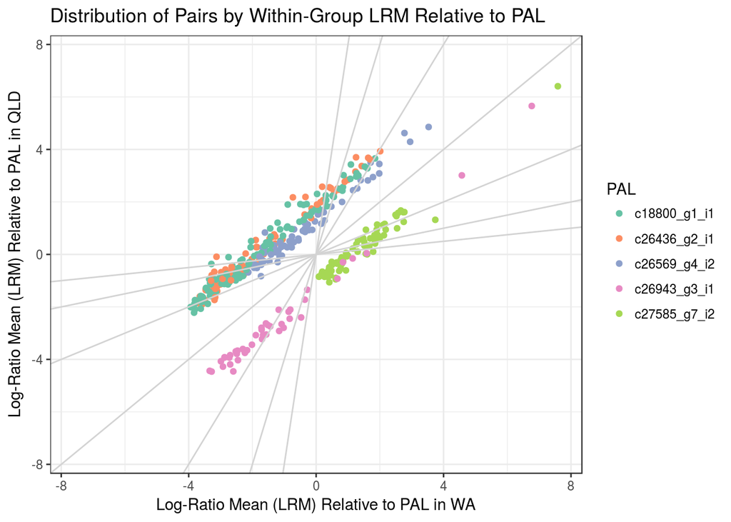

```r
bowtie(pd.d, prompt = FALSE)
```

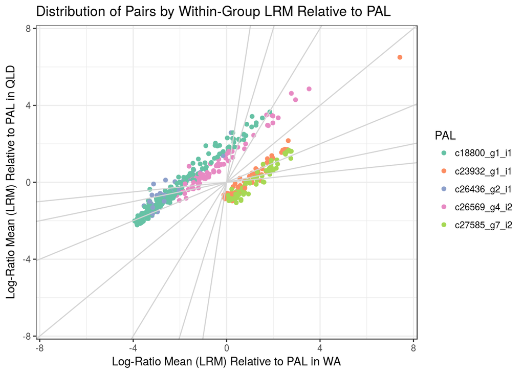

```r
bowtie(pd.f, prompt = FALSE)
```

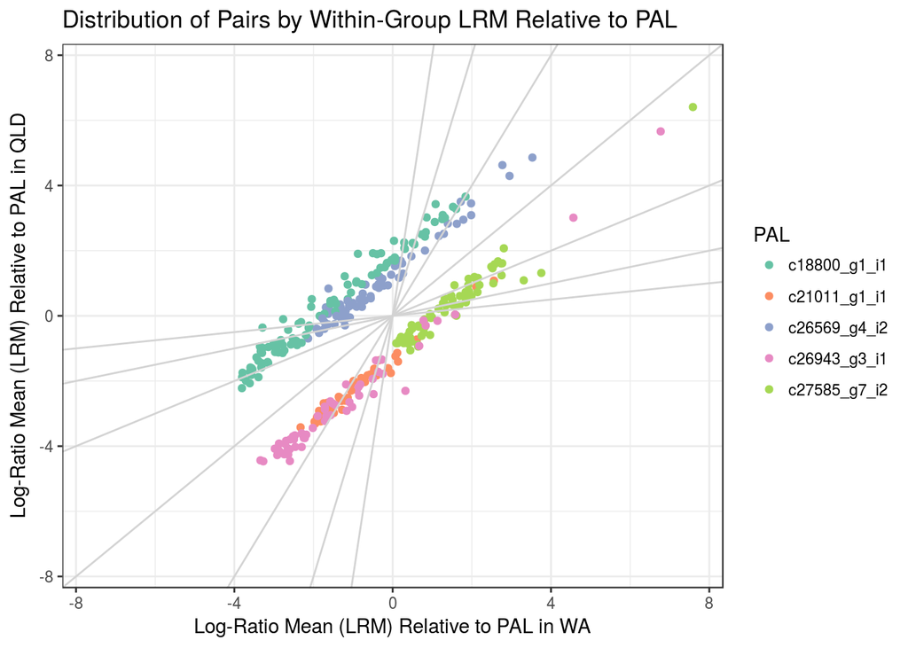

```r
bowtie(pd.dw, prompt = FALSE)
```

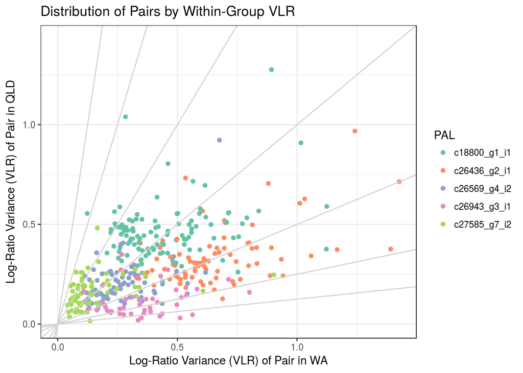

```r
geiser(pd.d, cutoff = 1000, k = 5, prompt = FALSE)
```

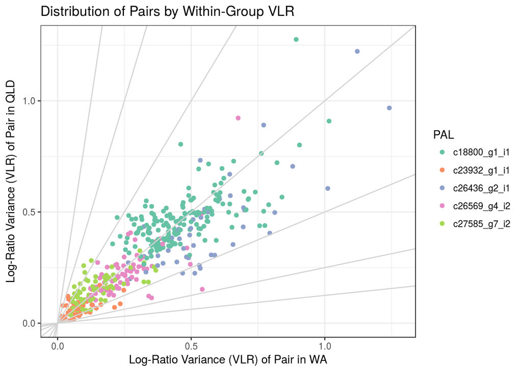

```r
geiser(pd.f, cutoff = 1000, k = 5, prompt = FALSE)
```

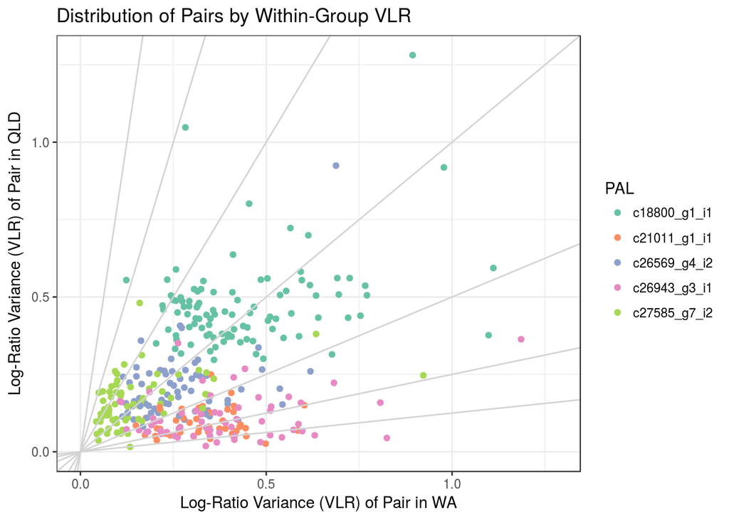

```r
geiser(pd.dw, cutoff = 1000, k = 5, prompt = FALSE)
```

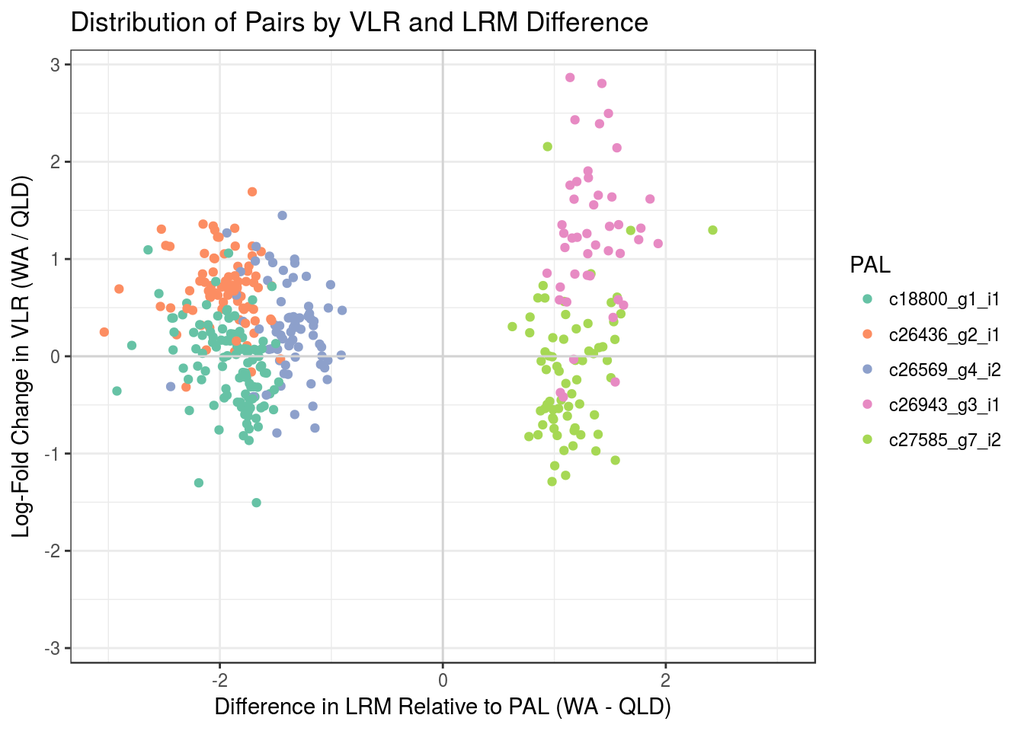

```r
gemini(pd.d, cutoff = 1000, k = 5, prompt = FALSE)
```

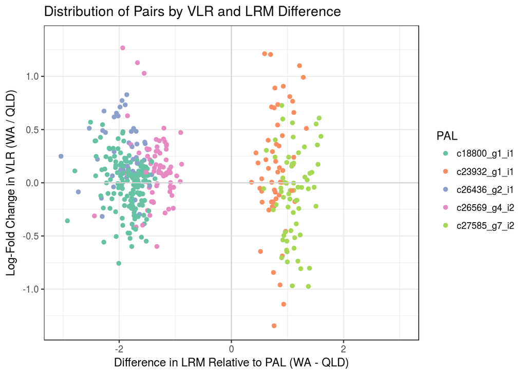

```r
gemini(pd.f, cutoff = 1000, k = 5, prompt = FALSE)
```

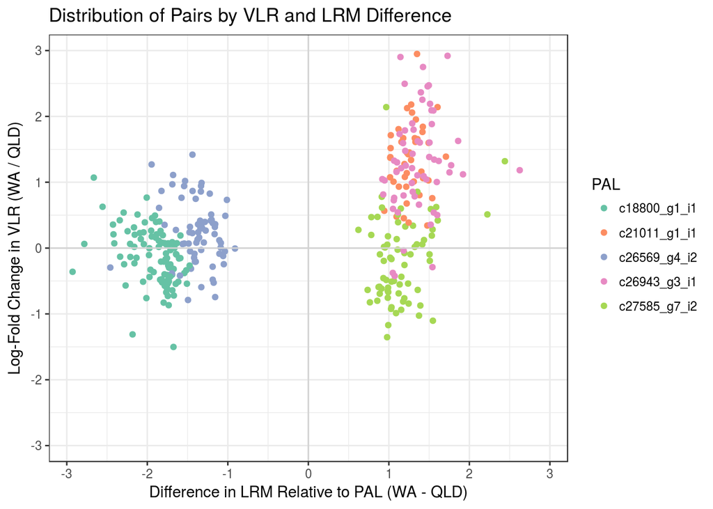

```r
gemini(pd.dw, cutoff = 1000, k = 5, prompt = FALSE)
```

```
## Red: Pair has higher LRM in group WA than in group QLD
```

```
## Blue: Pair has lower LRM in group WA than in group QLD
```

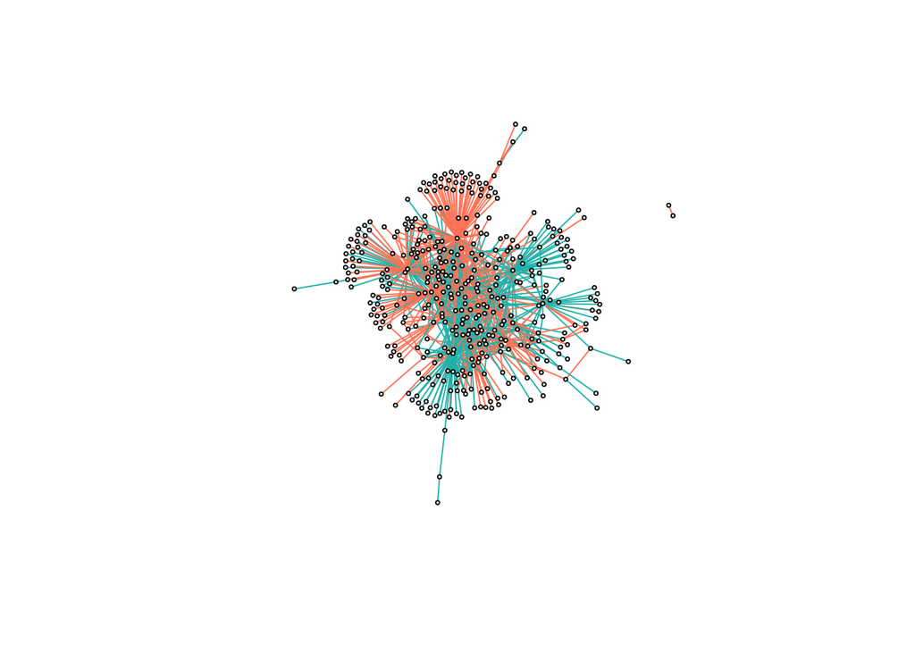

```
## IGRAPH UN-- 403 1000 --
## + attr: name (v/c), color (v/c), size (v/n), label (v/l), color
## | (e/c)
## + edges (vertex names):
##  [1] c17497_g2_i1--c8370_g1_i1  c17497_g2_i1--c25983_g1_i2
##  [3] c17497_g2_i1--c25076_g1_i1 c17497_g2_i1--c27236_g1_i2
##  [5] c17497_g2_i1--c23932_g1_i1 c17497_g2_i1--c25219_g1_i2
##  [7] c17497_g2_i1--c23538_g1_i2 c17497_g2_i1--c23846_g1_i2
##  [9] c17497_g2_i1--c20948_g1_i1 c17497_g2_i1--c26982_g5_i1
## [11] c17497_g2_i1--c20641_g1_i3 c17497_g2_i1--c26223_g1_i2
## [13] c17497_g2_i1--c24866_g2_i1 c17497_g2_i1--c23846_g1_i1
## + ... omitted several edges
```

```r
plot(pd.d, cutoff = 1000, prompt = FALSE)
```

```
## Red: Pair has higher LRM in group WA than in group QLD
## Blue: Pair has lower LRM in group WA than in group QLD
```

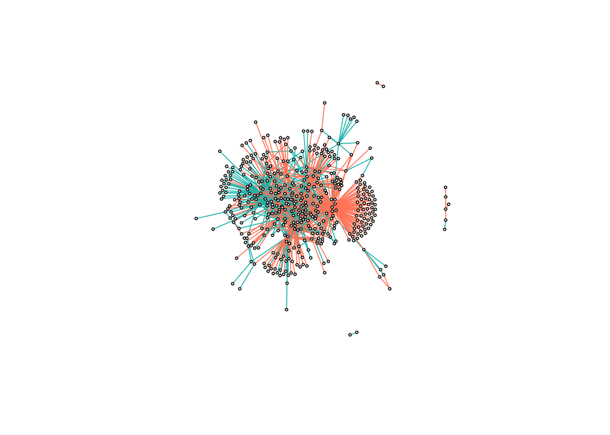

```
## IGRAPH UN-- 438 1000 --
## + attr: name (v/c), color (v/c), size (v/n), label (v/l), color
## | (e/c)
## + edges (vertex names):
##  [1] c17497_g2_i1--c25270_g1_i1 c17497_g2_i1--c25076_g1_i1
##  [3] c17497_g2_i1--c23932_g1_i1 c17497_g2_i1--c25219_g1_i2
##  [5] c17497_g2_i1--c23538_g1_i2 c17497_g2_i1--c23846_g1_i2
##  [7] c17497_g2_i1--c20948_g1_i1 c17497_g2_i1--c26982_g5_i1
##  [9] c17497_g2_i1--c26223_g1_i2 c17497_g2_i1--c23846_g1_i1
## [11] c17497_g2_i1--c25348_g1_i1 c17497_g2_i1--c19138_g1_i1
## [13] c17497_g2_i1--c26800_g1_i3 c22443_g1_i1--c26089_g2_i1
## + ... omitted several edges
```

```r
plot(pd.f, cutoff = 1000, prompt = FALSE)
```

```
## Red: Pair has higher LRM in group WA than in group QLD
## Blue: Pair has lower LRM in group WA than in group QLD
```

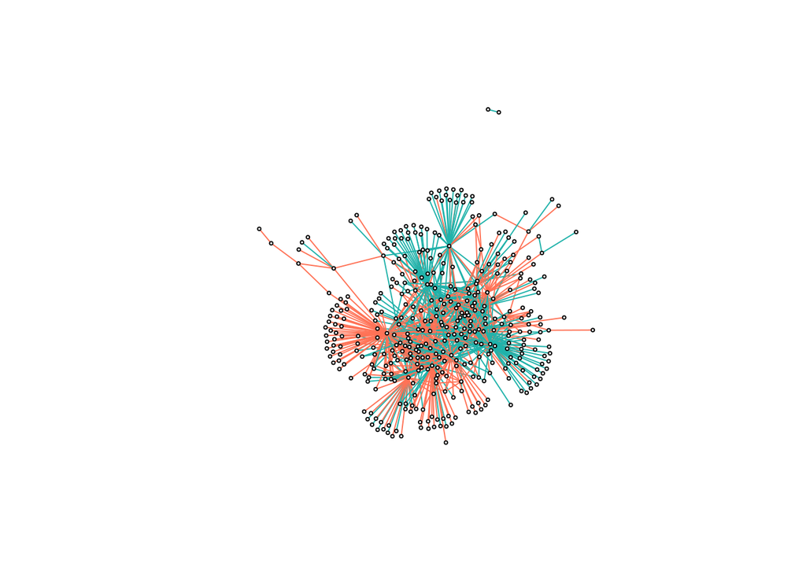

```
## IGRAPH UN-- 397 1000 --
## + attr: name (v/c), color (v/c), size (v/n), label (v/l), color
## | (e/c)
## + edges (vertex names):
##  [1] c17497_g2_i1--c8370_g1_i1  c17497_g2_i1--c25983_g1_i2
##  [3] c17497_g2_i1--c25076_g1_i1 c17497_g2_i1--c27468_g7_i1
##  [5] c17497_g2_i1--c27236_g1_i2 c17497_g2_i1--c23932_g1_i1
##  [7] c17497_g2_i1--c25219_g1_i2 c17497_g2_i1--c23538_g1_i2
##  [9] c17497_g2_i1--c23846_g1_i2 c17497_g2_i1--c20948_g1_i1
## [11] c17497_g2_i1--c26982_g5_i1 c17497_g2_i1--c27588_g1_i1
## [13] c17497_g2_i1--c26223_g1_i2 c17497_g2_i1--c24866_g2_i1
## + ... omitted several edges
```

```r
plot(pd.dw, cutoff = 1000, prompt = FALSE)
```